# Comparison of two data sets at different levels/options of the tuna atlas

Bastien Grasset

09/02/2022

The purpose of this markdown is to describe the loss of data from the World Tuna Atlas following the different filters. It describes the differences between the initial data and the final data, and is intended for users of the final data who might be tempted to use it without taking into account the various filtering specificities.

# The data

The analyzed data are *data/Les7entites_finies/entities/global_catch_firms_level0/Rds/georef_dataset_level0_step9global_catch_firms_level0.rds* for the initial data and *data/Les7entites_finies/entities/global_catch_firms_level0/Rds/georef_dataset_level0_step9global_catch_firms_level0ancient.rds* for the final data.

The filters used are:

- on species: SBF
- on gears: NULL
- on rfmos:
- on fleets:
- on initial dates:
- on final dates:
- on geographical categories:
- on catch types:

# Introduction to the two datasets

We first present the main characteristics of each dimension for each dataset.

## Comparison of the two datasets

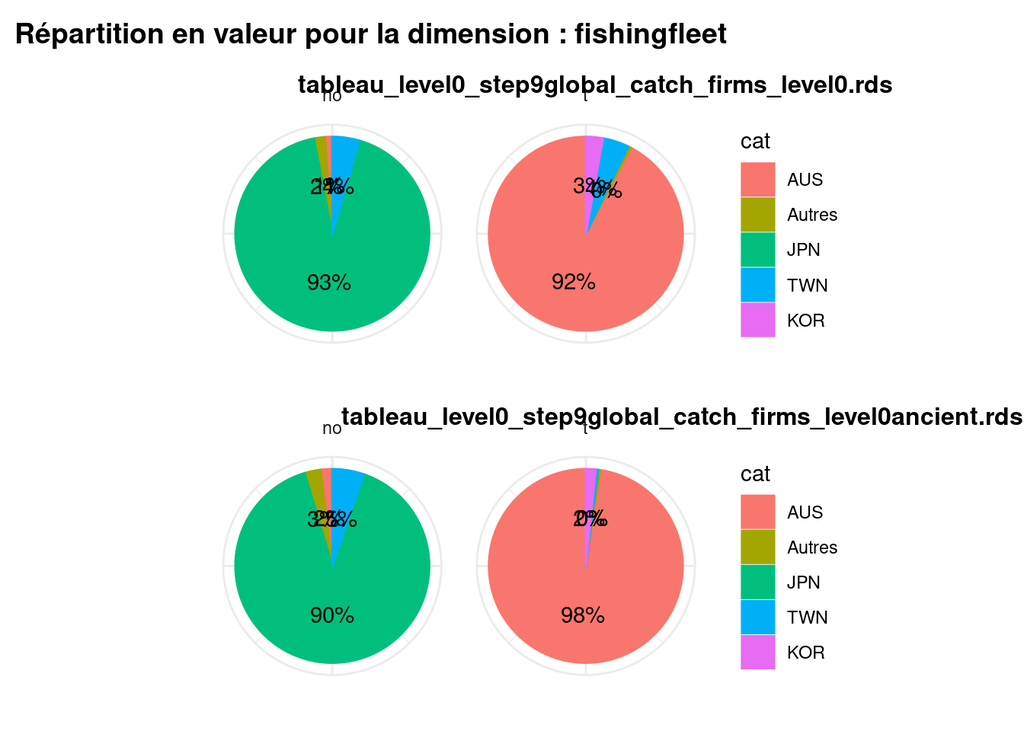

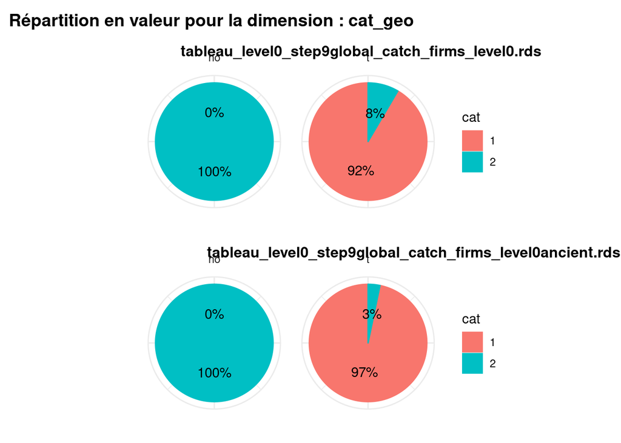

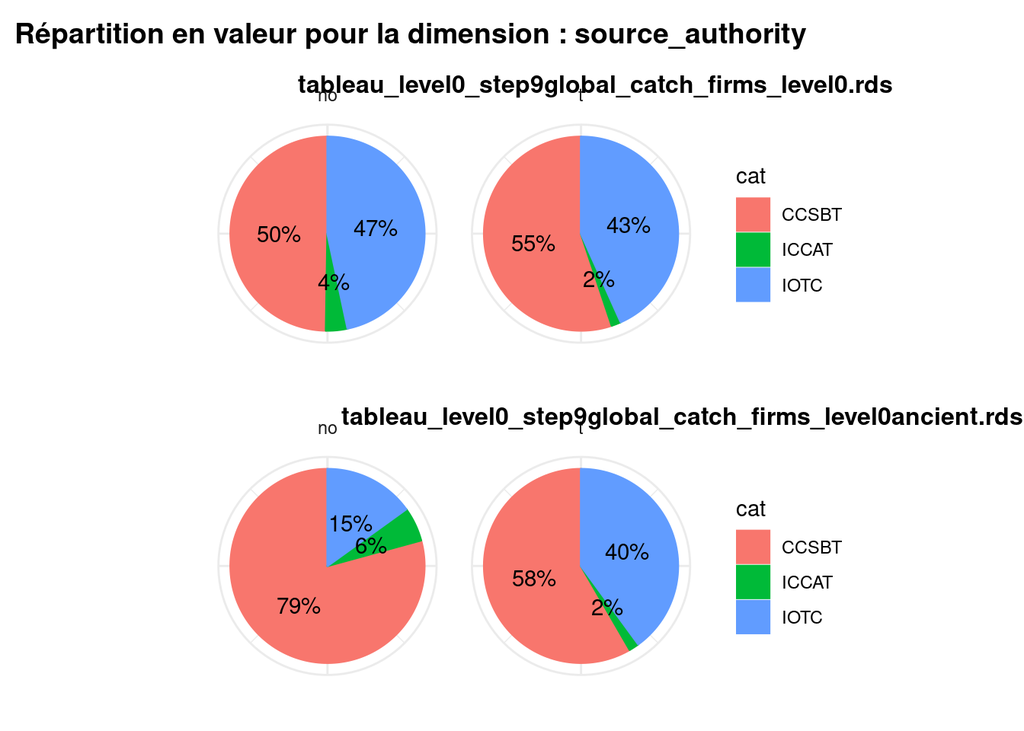

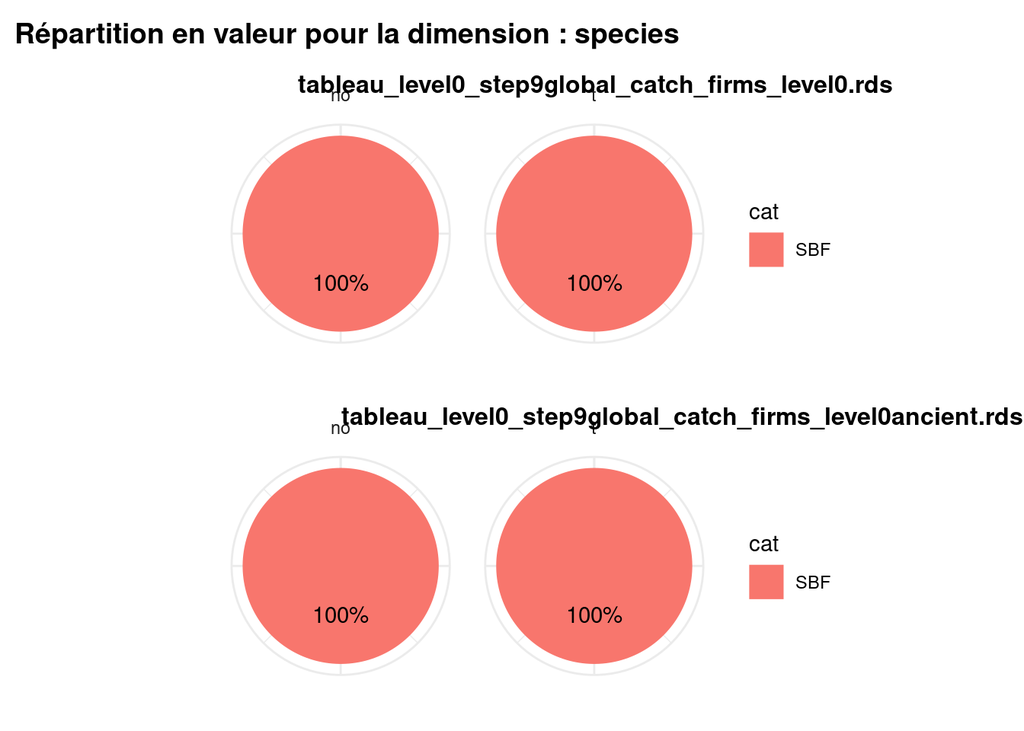

## Spatial footprints

### Initial data map

[interactive chart not shown]

### Final data map

[interactive chart not shown]

# Les pertes

## Les pertes générales

The number of lines goes from 0.045532 millions to 0.032324 millions, which correspond to a loss of 29.00817%.

The initial dataset has a total of 3.40164^{5} in tons and of 3.5502473^{7} in number of fish.

The final dataset has a total of 3.21313^{5} in tons and of 2.2287227^{7} in number of fish.

The loss is 1.8851^{4} in tons (5.54%). The loss is 1.3215246^{7} in number of fish (37.22%).

## The losses for each dimension

[output not shown]

[output cut: 6 more lines]

|  | Precision | unit | Dimension | value_sum_1 | nombre_lignes1 | value_sum1 | value_sum_2 | nombre_lignes2 | Loss (in %) | Perte en nombre de ligne | Perte en millions de tonnes |
| --- | --- | --- | --- | --- | --- | --- | --- | --- | --- | --- | --- |
| 1 | Autres | no | fishingfleet | 13055.77 | 31 | 13055.77 | 36.32 | 8 | 99.7218088247572 | 23 | 0.01301945 |
| 2 | Autres | no | source_authority | 16570099.77 | 15719 | 16570099.77 | 3354853.32 | 5073 | 79.7535719967484 | 10646 | 13.21524645 |
| 3 | JPN | no | fishingfleet | 32844171 | 30080 | 32844171 | 20096352 | 21252 | 38.8130332167617 | 8828 | 12.747819 |
| 4 | 25 | no | cat_geo | 35501165.107079 | 39060 | 35501165.107079 | 22285937.657079 | 28419 | 37.2247711029767 | 10641 | 13.21522745 |
| 5 | SBF | no | species | 35502473.107079 | 39145 | 35502473.107079 | 22287226.657079 | 28499 | 37.2234531666048 | 10646 | 13.21524645 |
| 6 | TWN | no | fishingfleet | 1586207 | 5552 | 1586207 | 1169858 | 3901 | 26.248087418603 | 1651 | 0.416349 |
| 7 | KOR | no | fishingfleet | 398115 | 1531 | 398115 | 360235 | 1397 | 9.51483867726662 | 134 | 0.03788 |
| 8 | 1 | no | cat_geo | 1308 | 85 | 1308 | 1289 | 80 | 1.4525993883792 | 5 | 1.9e-05 |
| 9 | AUS | no | fishingfleet | 431294 | 993 | 431294 | 431115 | 983 | 0.0415030118666153 | 10 | 0.000179 |
| 10 | BRA | no | fishingfleet | 318 | 6 | 318 | 318 | 6 | 0 | 0 | 0 |

[output cut: 6 more lines]

## Geographical data

[interactive chart not shown]

## Temporal data

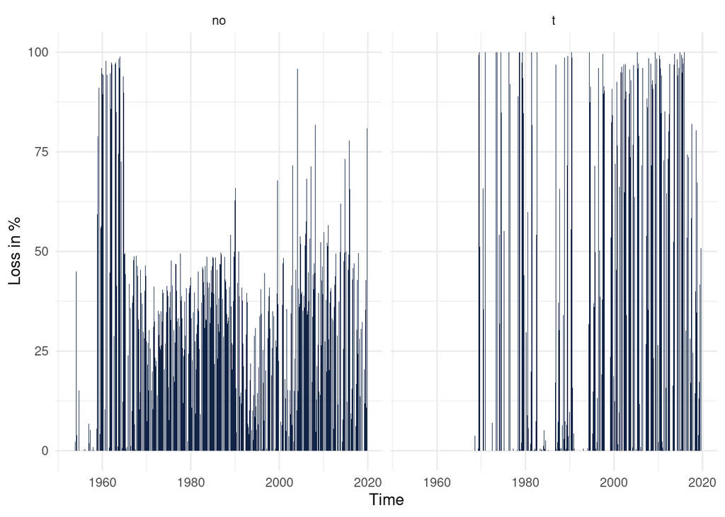

## Comparison of the two catch evolutions

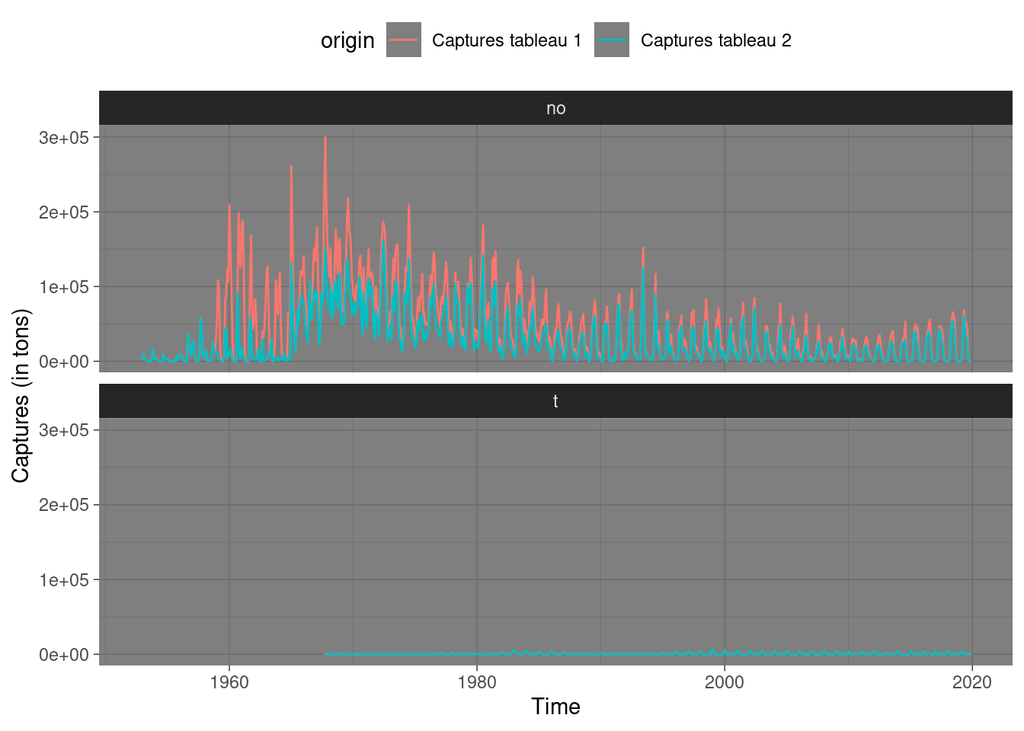

## Comparison of the evolution of the cumulative catches

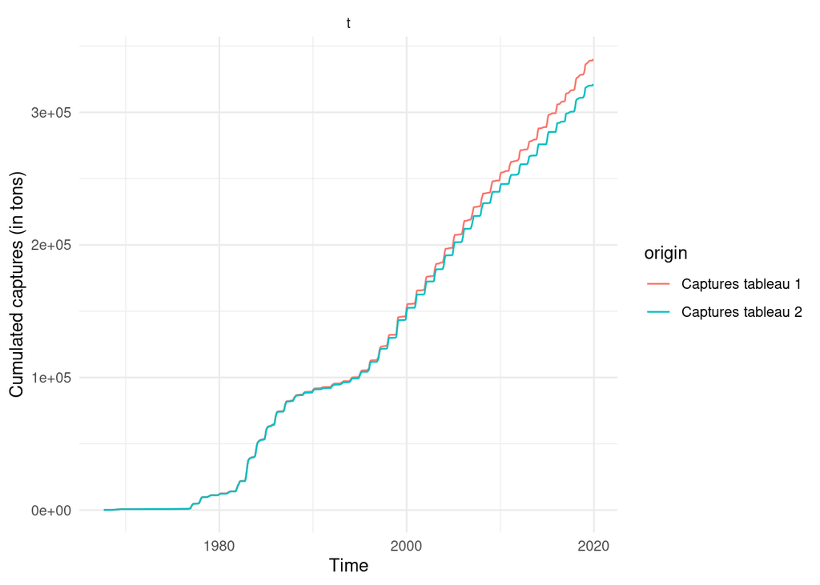

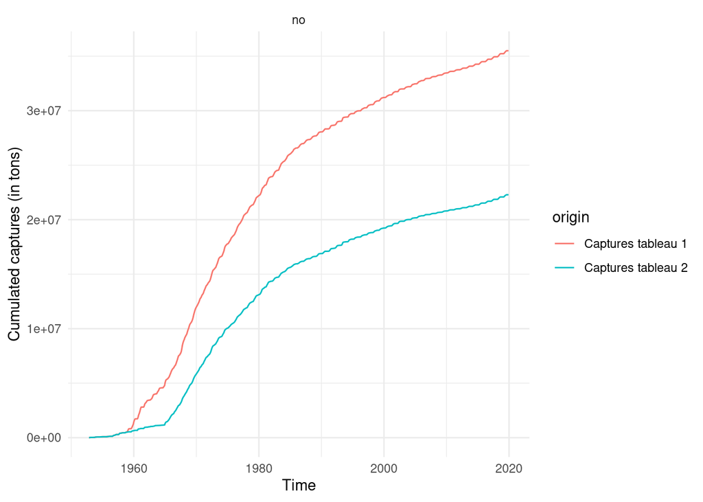